# Parsing Text for Emotion Terms

# Introduction

Use `lexicon` to leverage the [NRC emotion terms](http://saifmohammad.com/WebPages/NRC-Emotion-Lexicon.htm) to parse text for emotion terms. (`tidytext` use to support this feature but it has been dropped).

There are 2 parts to this analysis:

1. Emotion analysis of textual data
2. Unsupervised learning of emotion words

Load the NRC emotions lexicon in memory; reshape the wide data format to a narrow data format.

```r
head(nrc_emotions)
```

```
## # A tibble: 6 x 9
##   term        anger anticipation disgust  fear   joy sadness surprise trust
##   <chr>       <int>        <int>   <int> <int> <int>   <int>    <int> <int>
## 1 aback           0            0       0     0     0       0        0     0
## 2 abacus          0            0       0     0     0       0        0     1
## 3 abandon         0            0       0     1     0       1        0     0
## 4 abandoned       1            0       0     1     0       1        0     0
## 5 abandonment     1            0       0     1     0       1        1     0
## 6 abate           0            0       0     0     0       0        0     0
```

```r
nrc_data <-  nrc_emotions %>% gather("sentiment", "flag", anger:trust, -term) %>% filter(flag==1)
head(nrc_data)
```

```
## # A tibble: 6 x 3
##   term        sentiment  flag
##   <chr>       <chr>     <int>
## 1 abandoned   anger         1
## 2 abandonment anger         1
## 3 abhor       anger         1
## 4 abhorrent   anger         1
## 5 abolish     anger         1
## 6 abomination anger         1
```

# Data

In Warren Buffett’s annual shareholder letters in the past 40 years, only five of the annual shareholder letters showed negative net sentiment scores, whereas a majority of the letters (88%) displayed a positive net sentiment score. The years with negative net sentiment scores (1987, 1990, 2001, 2002 and 2008), coincided with lower annual returns on investments and global market decline.

With the explosion of digital and social media, there are various emoticons and emojis that can be embedded in text messages, emails, or other various social media communications, for use in expressing personal feelings or emotions. Emotions may also be expressed in textual forms using words.

R offers the lexicon or the `get_nrc_sentiment` function via `Syuzhet` for analysis of emotion words expressed in text. Both packages comprise of several words for emotion expressions of *anger*, *fear*, *anticipation*, *trust*, *surprise*, *sadness*, *joy*, and *disgust*.

## Test Dataset

Mr. Warren Buffett’s annual shareholder letters in the past 40-years (1977 – 2016):

```r
# Getting & Reading in HTML Letters
urls_77_97 <- paste('http://www.berkshirehathaway.com/letters/', seq(1977, 1997), '.html', sep='')
html_urls <- c(urls_77_97,
               'http://www.berkshirehathaway.com/letters/1998htm.html',
               'http://www.berkshirehathaway.com/letters/1999htm.html',
               'http://www.berkshirehathaway.com/2000ar/2000letter.html',
               'http://www.berkshirehathaway.com/2001ar/2001letter.html')

letters_html <- lapply(html_urls, function(x) read_html(x) %>% html_text())
# Getting & Reading in PDF Letters
urls_03_16 <- paste('http://www.berkshirehathaway.com/letters/', seq(2003, 2016), 'ltr.pdf', sep = '')
pdf_urls <- data.frame('year' = seq(2002, 2016),
                       'link' = c('http://www.berkshirehathaway.com/letters/2002pdf.pdf', urls_03_16))
download_pdfs <- function(x) {
  myfile = paste0(x['year'], '.pdf')
  download.file(url = x['link'], destfile = myfile, mode = 'wb')
  return(myfile)
}
pdfs <- apply(pdf_urls, 1, download_pdfs)
letters_pdf <- lapply(pdfs, function(x) pdf_text(x) %>% paste(collapse=" "))
tmp <- lapply(pdfs, function(x) if(file.exists(x)) file.remove(x))
# Combine letters in a data frame
letters <- do.call(rbind, Map(data.frame, year=seq(1977, 2016), text=c(letters_html, letters_pdf)))
letters$text <- as.character(letters$text)
```

# Emotion Analysis of Textual Data

## Descriptive Statistics

Analysis steps of emotion terms in textual data included word tokenization, pre-processing of tokens to exclude stop words and numbers and then invoking the `get_sentiment` using `tidytext` followed by aggregation and presentation of results. Word tokenization is the process of separating text into single words or unigrams.

Emotion words frequency and proportions

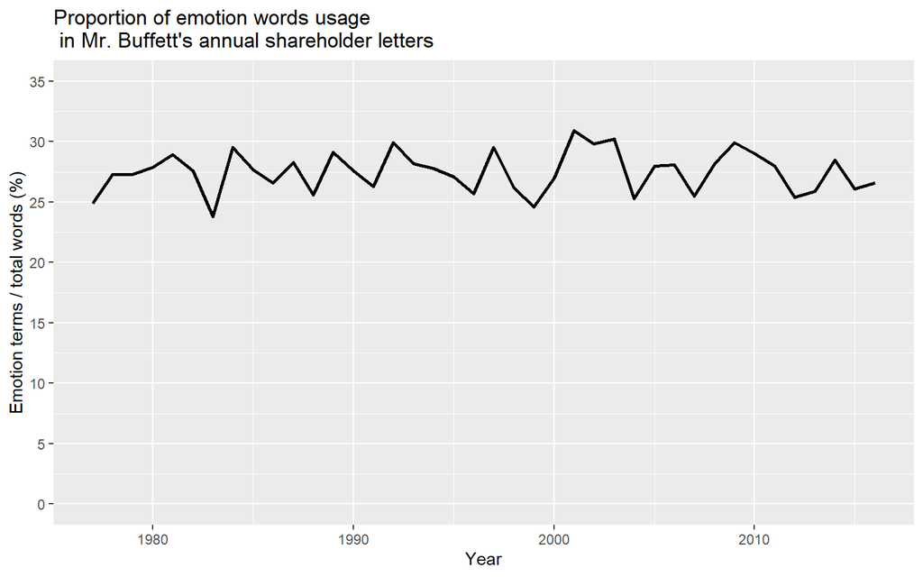

```r
total_words_count <- letters %>%
    unnest_tokens(word, text) %>%
    anti_join(stop_words, by = "word") %>%
    filter(!grepl('[0-9]', word)) %>%
    group_by(year) %>%
    summarize(total= n()) %>%
    ungroup()

emotion_words_count <- letters %>%
  unnest_tokens(word, text) %>%
  anti_join(stop_words, by = "word") %>%
  filter(!grepl('[0-9]', word)) %>%
  inner_join(nrc_data, by=c("word"="term"))  %>%
  group_by(year) %>%
  summarize(emotions= n()) %>%
  ungroup()

emotions_to_total_words <- total_words_count %>%
     left_join(emotion_words_count, by="year") %>%
               mutate(percent_emotions=round((emotions/total)*100,1))

ggplot(emotions_to_total_words, aes(x=year, y=percent_emotions)) +
     geom_line(size=1) +
     scale_y_continuous(limits = c(0, 35), breaks = c(0, 5, 10, 15, 20, 25, 30, 35)) +
     xlab("Year") +
     ylab("Emotion terms / total words (%)") + theme(legend.position="none") +
     ggtitle("Proportion of emotion words usage \n in Mr. Buffett's annual shareholder letters")
```

Depicting distribution of emotion words usage

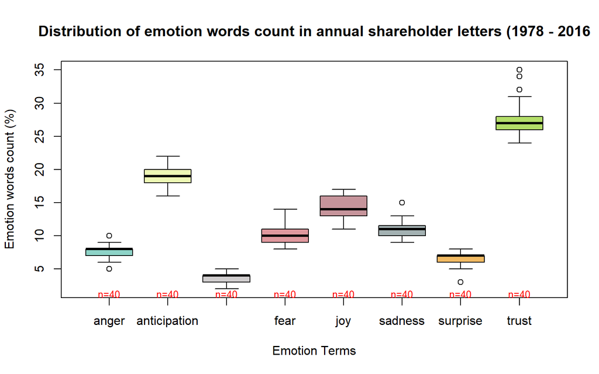

```r
### pull emotion words and aggregate by year and emotion terms
emotions <- letters %>%
  unnest_tokens(word, text) %>%
  anti_join(stop_words, by = "word") %>%
  filter(!grepl('[0-9]', word)) %>%
  inner_join(nrc_data, by=c("word"="term"))  %>%
  group_by(year, sentiment) %>%
  summarize( freq = n()) %>%
  mutate(percent=round(freq/sum(freq)*100)) %>%
  select(-freq) %>%
  ungroup()
### need to convert the data structure to a wide format
emo_box = emotions %>%
spread(sentiment, percent, fill=0) %>%
ungroup()
### color scheme for the box plots (This step is optional)
cols  <- colorRampPalette(brewer.pal(7, "Set3"), alpha=TRUE)(8)
boxplot2(emo_box[,c(2:9)], col=cols, lty=1, shrink=0.8, textcolor="red",
         xlab="Emotion Terms", ylab="Emotion words count (%)",
         main="Distribution of emotion words count in annual shareholder letters (1978 - 2016")
```

Terms for all eight emotions types were expressed albeit at variable rates. Looking at the box plot, *anger*, *sadness*, *surprise*, and *trust* showed outliers. Besides, *anger*, *disgust* and *surprise* were skewed to the left, whereas *joy* was skewed to the right. The `n =` below each box plot indicates the number of observations that contributed to the distribution of the box plot above it.

Emotion words usage over time

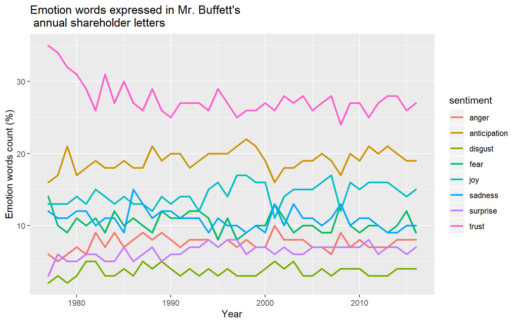

```r
## yearly line chart
ggplot(emotions, aes(x=year, y=percent, color=sentiment, group=sentiment)) +
geom_line(size=1) +
geom_point(size=0.5) +
xlab("Year") +
  ylab("Emotion words count (%)") +
  ggtitle("Emotion words expressed in Mr. Buffett's \n annual shareholder letters")
```

Emotion terms referring to *trust* and *anticipation* were expressed consistently higher than the other emotion terms in all of the annual shareholder letters. Emotion terms referring to *disgust*, *anger* and *surprise* were expressed consistently lower than the other emotion terms at almost all time points.

Average emotion words expression using bar charts with error bars

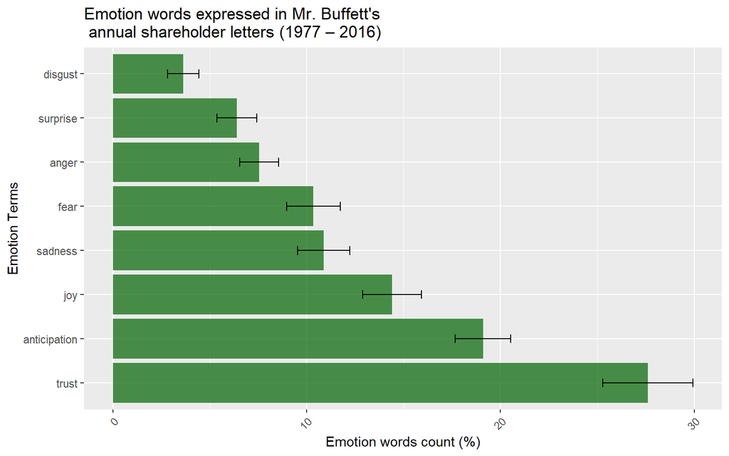

```r
### calculate overall averages and standard deviations for each emotion term
overall_mean_sd <- emotions %>%
     group_by(sentiment) %>%
     summarize(overall_mean=mean(percent), sd=sd(percent))
### draw a bar graph with error bars
ggplot(overall_mean_sd, aes(x = reorder(sentiment, -overall_mean), y=overall_mean)) +
     geom_bar(stat="identity", fill="darkgreen", alpha=0.7) +
     geom_errorbar(aes(ymin=overall_mean-sd, ymax=overall_mean+sd), width=0.2,position=position_dodge(.9)) +
     xlab("Emotion Terms") +
     ylab("Emotion words count (%)") +
     ggtitle("Emotion words expressed in Mr. Buffett's \n annual shareholder letters (1977 – 2016)") +
     theme(axis.text.x=element_text(angle=45, hjust=1)) +
     coord_flip( )
```

Emotion words referring to *trust*, *anticipation* and *joy* were over-represented and accounted on average for approximately 60% of all emotion words in all shareholder letters. On the other hand, *disgust*, *surprise* and *anger* were the least expressed emotion terms and accounted on average for approximately 18% of all emotion terms in all shareholder letters.

Emotion terms usage over time compared to 40-years averages

The 40-year averages of each emotion terms shown in the above bar chart were subtracted from the yearly percent emotions for any given year. The results were showing higher or lower than average emotion expression levels for the respective years.

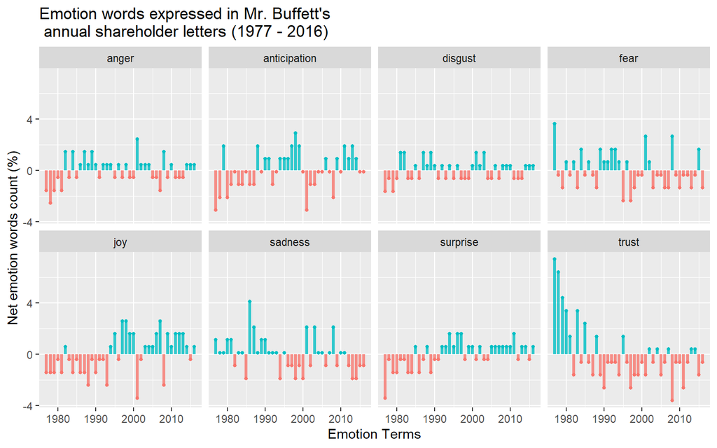

```r
## Hi / Low plots compared to the 40-years average
emotions_diff <- emotions  %>%
     left_join(overall_mean_sd, by="sentiment") %>%
     mutate(difference=percent-overall_mean)

ggplot(emotions_diff, aes(x=year, y=difference, colour=difference>0)) +
geom_segment(aes(x=year, xend=year, y=0, yend=difference),
size=1.1, alpha=0.8) +
geom_point(size=1.0) +
xlab("Emotion Terms") +
     ylab("Net emotion words count (%)") +
     ggtitle("Emotion words expressed in Mr. Buffett's \n annual shareholder letters (1977 - 2016)") +
theme(legend.position="none") +
facet_wrap(~sentiment, ncol=4)
```

Red lines show lower than the 40-year average emotion expression levels, while blue lines indicate higher than the 40-year average emotion expression levels for the respective years.

## Observations

Excluding stop words and numbers, approximately 1 in 4 words in the annual shareholder letters represented emotion terms. Emotion terms referring to *trust*, *anticipation* and *joy* accounted for approximately 60% of all emotion terms. There were also very limited emotions of fear (approximately 1 in 10 emotion terms).

# Unsupervised Learning of Emotion Words

Now evaluate and understand the co-occurrence and/or co-expression of emotion words in individual letters, and if there were any differential expression profiles /patterns of emotions words among the 40 annual shareholder letters? Differential expression of emotion words is used to refer to quantitative differences in emotion word frequency counts among letters, as well as qualitative differences in certain emotion words occurring uniquely in some letters but not present in others.

Analysis of emotions terms usage

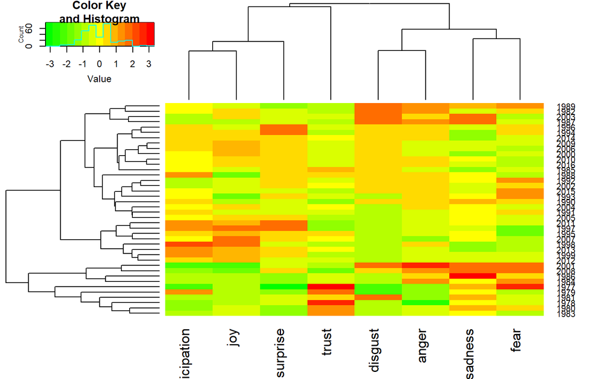

```r
# pull emotion words and aggregate by year and emotion terms

emotions <- letters %>%
  unnest_tokens(word, text) %>%
  anti_join(stop_words, by = "word") %>%
  filter(!grepl('[0-9]', word)) %>%
  left_join(get_sentiments("nrc"), by = "word") %>%
  filter(!(sentiment == "negative" | sentiment == "positive")) %>%
  group_by(year, sentiment) %>%
  summarize( freq = n()) %>%
  mutate(percent=round(freq/sum(freq)*100)) %>%
  select(-freq) %>%
  spread(sentiment, percent, fill=0) %>%
  ungroup()
## Normalize data
sd_scale <- function(x) {
     (x - mean(x))/sd(x)
 }
emotions[,c(2:9)] <- apply(emotions[,c(2:9)], 2, sd_scale)
emotions <- as.data.frame(emotions)
rownames(emotions) <- emotions[,1]
emotions3 <- emotions[,-1]
emotions3 <- as.matrix(emotions3)
## Using a heatmap and clustering to visualize and profile emotion terms expression data

heatmap.2(
     emotions3,
     dendrogram = "both",
     scale      = "none",
     trace      = "none",
     key        = TRUE,
     col    = colorRampPalette(c("green", "yellow", "red"))
 )
```

The colors of the heatmap represent high levels of emotion terms expression (red), low levels of emotion terms expression (green) and average or moderate levels of emotion terms expression (yellow).

Co-expression profiles of emotion words usage

Based on the expression profiles combined with the vertical dendrogram, there are about four co-expression profiles of emotion terms:

- emotion terms referring to *fear* and *sadness* appeared to be co-expressed together
- *anger* and *disgust* showed similar expression profiles and hence were co-expressed emotion terms
- emotion terms referring to *joy*, *anticipation* and *surprise* appeared to be similarly expressed
- emotion terms referring to *trust* did show the least co-expression pattern

Emotion expression profiling of annual shareholder letters

Looking at the horizontal dendrogram and heatmap above, approximately six groups of emotions expressions profiles can be recognized among the 40 annual shareholder letters.

Numbers of emotion terms expressed uniquely or in common among the heatmap groups

The next steps of the analysis attempts to determine the numbers of emotion words that were uniquely expressed in any of the heatmap groups. Also wanted to see if some emotion words were expressed in all of the heatmap groups, if any? This includes a word stemming procedure.

Examples of word stemmer output

There are several word stemmers in R. One such function, the `wordStem`, in `SnowballC` extracts the stems of each of the given words in a vector.

```r
Before <- c("produce",  "produces", "produced", "producing", "product", "products", "production")
wstem <- as.data.frame(wordStem(Before))
names(wstem) <- "After"
pander::pandoc.table(cbind(Before, wstem))
```

```
##
## ----------------------
##    Before      After
## ------------ ---------
##   produce     produc
##
##   produces    produc
##
##   produced    produc
##
##  producing    produc
##
##   product     product
##
##   products    product
##
##  production   product
## ----------------------
```

Analysis of unique and commonly expressed emotion words

## pull emotions words for selected heatmap groups and apply stemming

```r
set.seed(456)
emotions_final <- letters  %>%
   unnest_tokens(word, text) %>%
filter(!grepl('[0-9]', word)) %>%
   left_join(get_sentiments("nrc"), by = "word") %>%
filter(!(sentiment == "negative" | sentiment == "positive" | sentiment == "NA")) %>%
subset(year==1987 | year==1989 |  year==2001 |  year==2008 | year==2012 | year==2013) %>%
mutate(word = wordStem(word)) %>%
ungroup()
group1 <- emotions_final %>%
     subset(year==1987| year==1989 ) %>%
     select(-year, -sentiment) %>%
     unique()
group4 <- emotions_final %>%
     subset(year==2012 | year==2013) %>%
     select(-year, -sentiment) %>%
     unique()
group5 <- emotions_final %>%
     subset(year==2001 | year==2008 ) %>%
     select(-year, -sentiment) %>%
     unique()
```

Unique and common emotion words among two groups

Draw a two-way Venn diagram to find out which emotions terms were unique or commonly expressed between heatmap **Group-1** & **Group-4**.

```r
# common and unique w__ords between two groups
emo_venn2 <- venn(list(group1$word, group4$word))
```

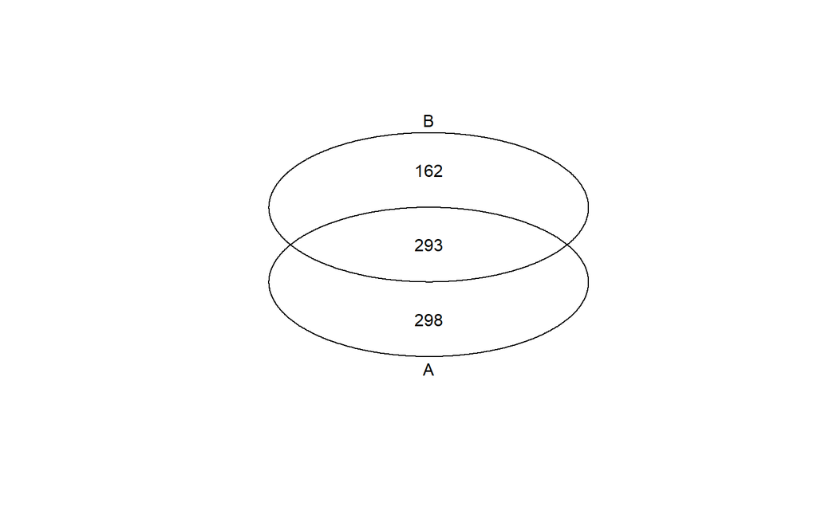

A total of 293 emotion terms were expressed in common between **Group-1** (A) and **Group-4** (B). There were also 298 and 162 unique emotion words usage in heatmap **Groups-1 & 4**, respectively.

Unique and common emotion words among three groups

Draw a three way Venn diagram to find out which emotions terms were uniquely or commonly expressed among **Group-1**, **Group-4** & **Group-5**.

```r
# common and unique words among three groups
emo_venn3 <- venn(list(group1$word, group4$word, group5$word))
```

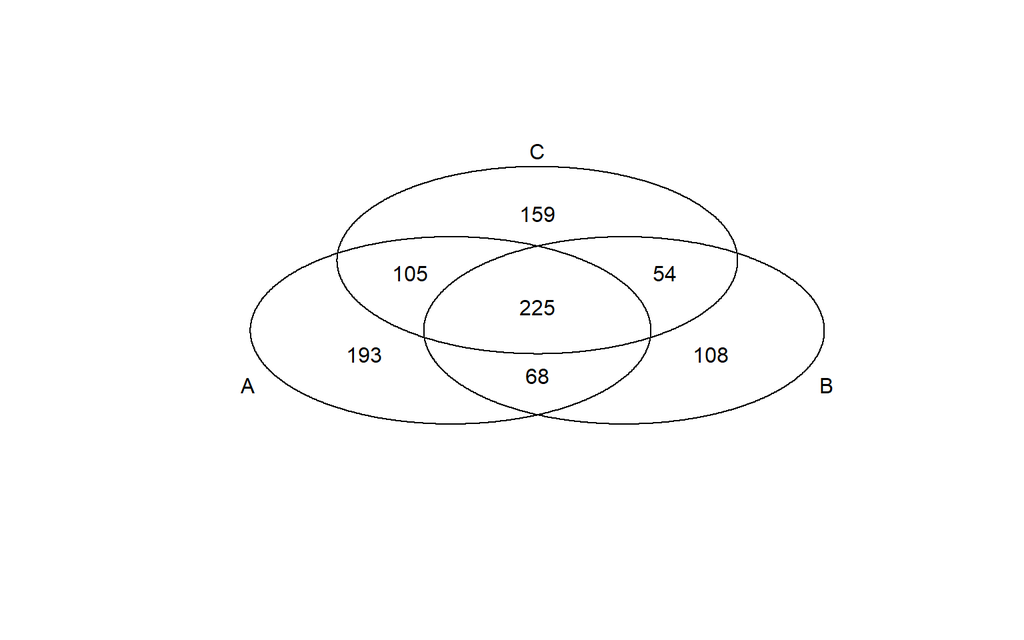

review a list of those emotion words that were expressed uniquely and/or in common among several groups. For instance the R code below requested for a list of the 159 unique emotion words that were expressed solely in **Group-5** letters of the 2001 & 2008.

```r
# The code below pulled a list of all common/unique emotion words expressed in all possible combinations of the the three heatmap groups
venn_list <- (attr(emo_venn3, "intersection"))
## and then print only the list of unique emotion words expressed in group-5.
print(venn_list$'C')
```

```
##   [1] "manual"          "familiar"        "sentenc"
##   [4] "variabl"         "safeguard"       "abus"
##   [7] "egregi"          "gorgeou"         "hesit"
##  [10] "strive"          "loyalti"         "loom"
##  [13] "approv"          "like"            "winner"
##  [16] "entertain"       "tender"          "withdraw"
##  [19] "harm"            "strike"          "straightforward"
##  [22] "victim"          "iron"            "bounti"
##  [25] "chaotic"         "bloat"           "proviso"
##  [28] "frank"           "honor"           "child"
##  [31] "lemon"           "prospect"        "relev"
##  [34] "threaten"        "terror"          "quak"
##  [37] "scarciti"        "question"        "manipul"
##  [40] "deton"           "terrorist"       "attack"
##  [43] "ill"             "nation"          "hydra"
```

[output cut: 38 more lines]

The output from the above code included a list of 159 words, but the list above contained only the first 51 for space considerations. Notice some of the emotions words were truncated and did not look proper words due to stemming.

Dispersion Plot

Dispersion plot is a graphical display that can be used to represent the approximate locations and densities of emotion terms across the length of the text document. Shown below are three dispersion plots of unique emotion words of heatmap **Group-1** (1987, 1989), **Group-5** (2001, 2008) and **Group-4** (2012 and 2013) shareholder letters. For the dispersion plots, all words in the listed years were sequentially ordered by year of the letters and the presence and approximate locations of the unique words were identified/displayed by a stripe. Each stripe represented an instance of a unique word in the shareholder letters.

Confirmation of emotion words expressed uniquely in heatmap group-1

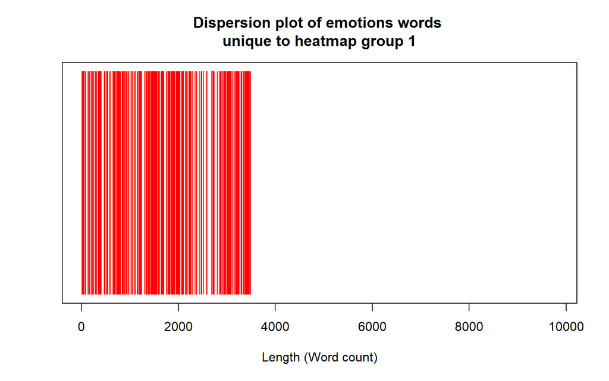

```r
## Confirmation of unique emotion words in heatmap group-1
group1_U <- as.data.frame(venn_list$'A')
names(group1_U) <- "terms"
uniq1 <- sqldf( "select t1.*, g1.terms
from emotions_final t1
left join
group1_U g1
on t1.word = g1.terms "
)
uniq1a <- !is.na(uniq1$terms)
uniqs1 <- rep(NA, length(emotions_final))
uniqs1[uniq1a] <- 1
plot(uniqs1, main="Dispersion plot of emotions words \n unique to heatmap group 1 ", xlab="Length (Word count)", ylab=" ", col="red", type='h', ylim=c(0,1), yaxt='n')
```

Heatmap **Group-1** letters included those in 1987/1989. The dispersion plot above confirmed that the unique emotion words in **Group-1** were confined at the start of the dispersion plot.

Confirmation of emotion words expressed uniquely in heatmap group-5

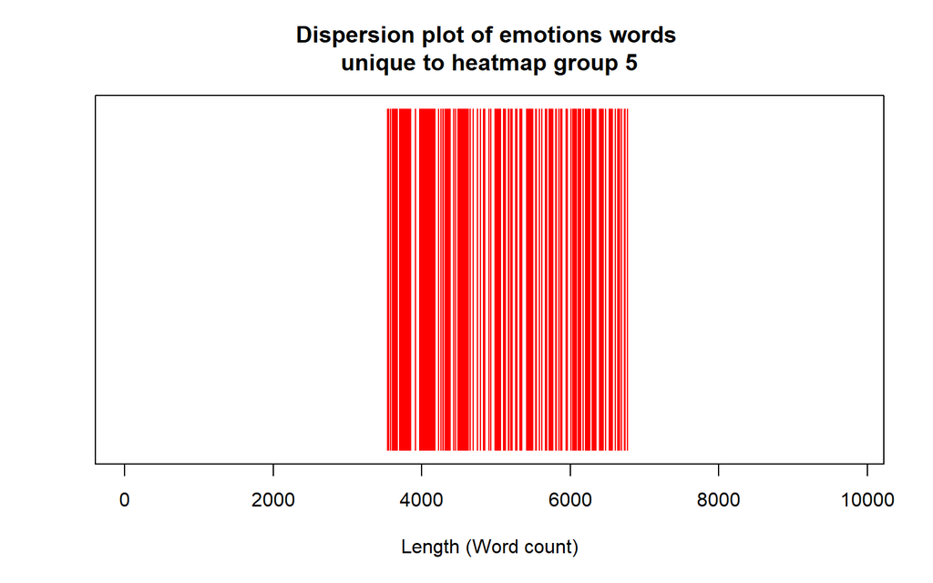

```r
## confirmation of unique emotion words in heatmap group-5
group5_U <- as.data.frame(venn_list$'C')
names(group5_U) <- "terms"
uniq5 <- sqldf( "select t1.*, g5.terms
from emotions_final t1
left join
group5_U g5
on t1.word = g5.terms "
)
uniq5a <- !is.na(uniq5$terms)
uniqs5 <- rep(NA, length(emotions_final))
uniqs5[uniq5a] <- 1

plot(uniqs5, main="Dispersion plot of emotions words \n unique to heatmap group 5 ", xlab="Length (Word count)", ylab=" ", col="red", type='h', ylim=c(0,1), yaxt='n')
```

Heatmap **Group-5** letters included those in 2001 & 2008. As expected, the dispersion plot above confirmed that the unique emotion words in group-5 were confined at the middle parts of the dispersion plot.

Confirmation of emotion words expressed uniquely in heatmap group-4

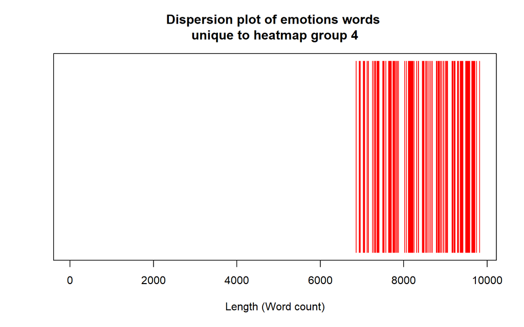

```r
## confirmation of unique emotion words in heatmap group-4
group4_U <- as.data.frame(venn_list$'B')
names(group4_U) <- "terms"
uniq4 <- sqldf( "select t1.*, g4.terms
from emotions_final t1
left join
group4_U g4
on t1.word = g4.terms "
)
uniq4a <- !is.na(uniq4$terms)
uniqs4 <- rep(NA, length(emotions_final))
uniqs4[uniq4a] <- 1

plot(uniqs4, main="Dispersion plot of emotions words \n unique to heatmap group 4 ", xlab="Length (Word count)", ylab=" ", col="red", type='h', ylim=c(0,1), yaxt='n')
```

Heatmap **Group-4** letters included those in 2012 & 2013. As expected, the dispersion plot above confirmed that the unique emotion words in **Group-4** were confined towards the end of the dispersion plot.

Annual Returns on Investment in S&P500 (1977 – 2016)

Lastly a graph of the annual returns on investment in S&P 500 during the same 40 years of the annual shareholder letters is being displayed below for perspective. The S&P 500 data was downloaded from [here](http://pages.stern.nyu.edu/~adamodar/New_Home_Page/datafile/histretSP.html) using code from [here](https://github.com/michaeltoth/michaeltoth/blob/master/content/_R/berkshire_hathaway_sentiment.Rmd)

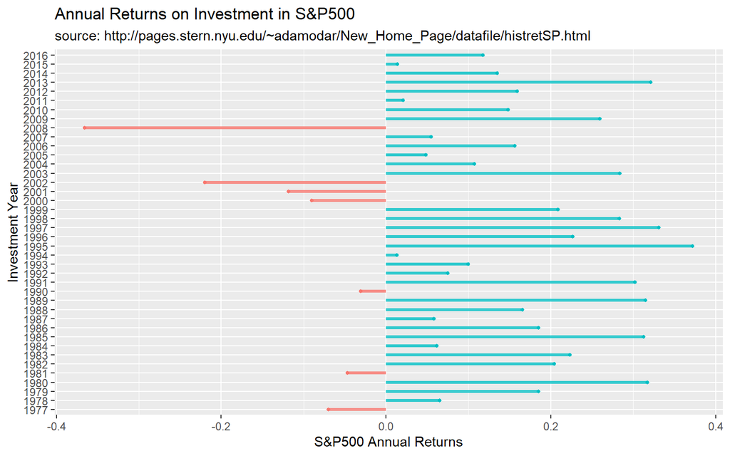

```r
## You need to first download the raw data before running the code to recreate the graph below.
sp500 <- readHTMLTable('http://pages.stern.nyu.edu/~adamodar/New_Home_Page/datafile/histretSP.html',
                       header = T, which = 1, skip = c(1, seq(92,101))) %>%
         select(1, 2) %>%
         `colnames<-`(c("year", "return")) %>%
         mutate(return = as.numeric(strsplit(as.character(return), split = '%')) / 100)

ggplot(sp500[50:89,], aes(x=year, y=return, colour=return>0)) +
geom_segment(aes(x=year, xend=year, y=0, yend=return),
size=1.1, alpha=0.8) +
geom_point(size=1.0) +
xlab("Investment Year") +
     ylab("S&P500 Annual Returns") +
     labs(title="Annual Returns on Investment in S&P500", subtitle= "source: http://pages.stern.nyu.edu/~adamodar/New_Home_Page/datafile/histretSP.html") +
     theme(legend.position="none") +
     coord_flip()
```

#Reference:

https://datascienceplus.com/parsing-text-for-emotion-terms-analysis-visualization-using-r-updated-analysis/